# smoof: Single- and Multi-Objective Optimization Test Functions

Benchmarking algorithms for optimization problems usually is carried out by running the algorithms under consideration on a diverse set of benchmark or test functions. A vast variety of test functions was proposed by researchers and is being used for investigations in the literature. The *smoof* package implements a large set of test functions and test function generators for both the single- and multi-objective case in continuous optimization and provides functions to easily create own test functions. Moreover, the package offers some additional helper methods, which can be used in the context of optimization.

Jakob Bossek (PhD Student, Department of Information Systems, University of Münster)  
2017-05-10

## 1 Introduction

The task of global optimization is to find the best solution $\mathbf{x} = \left(x_1, \ldots, x_n\right)^T \in \mathbf{X}$ according to a set of objective functions $\mathcal{F} = \{f_1, \ldots, f_m\}$. If input vectors as well as output values of the objective functions are real-valued, i. e., $f_i : \mathbb{R}^n \to \mathbb{R}$ the optimization problem is called continuous. Otherwise, i.e., if there is at least one non-continuous parameter, the problem is termed *mixed*. For $m = 1$, the optimization problem is termed single-objective and the goal is to minimize a single objective $f$, i. e.,

$$\begin{aligned}
\mathbf{x}^{*} = \text{arg\,min}_{\mathbf{x} \in X} f\left(\mathbf{x}\right).
\end{aligned}$$
Clearly, talking about minimization problems is no restriction: we can maximize $f$ by minimizing $-f$. Based on the structure of the search space, there may be multiple or even infinitely many global optima, i. e., $\mathbf{x}^{*} \in \mathbf{X}^{*} \subseteq \mathbf{X}$. We are faced with a multi-objective optimization problem if there are at least two objective functions. In this case as a rule no global optimum exists since the objectives are usually conflicting and there is just a partial order on the search space; for sure $\left(1, 4\right)^T \leq \left(3, 7\right)^T$ makes sense, but $\left(1, 4\right)^T$ and $\left(3, 2\right)^T$ are not comparable. In the field of multi-objective optimization we are thus interested in a set

$$\begin{aligned}
PS = \{\mathbf{x} \in \mathbf{X} \, | \, \nexists \, \tilde{\mathbf{x}} \in \mathbf{X} \, : \, f\left(\tilde{\mathbf{x}}\right) \preceq f\left(\mathbf{x}\right)\} \subseteq \mathbf{X}
\end{aligned}$$

of optimal trade-off solutions termed the Pareto-optimal set, where $\preceq$ defines the dominance relation. A point $\mathbf{x} \in X$ dominates another point $\tilde{\mathbf{x}} \in X$, i. e., $\mathbf{x} \preceq \tilde{\mathbf{x}}$ if

$$\begin{aligned}
& \forall \, i \in \{1, \ldots, m\} \, : \, f_i(\mathbf{x}) \leq f_i(\tilde{\mathbf{x}})\\
\text{and } & \exists \, i \in \{1, \ldots, m\} \, : \, f_i(\mathbf{x}) < f_i(\tilde{\mathbf{x}}).
\end{aligned}$$

Hence, all trade-off solutions $\mathbf{x}^{*} \in PS$ are non-dominated. The image of the Pareto-set $PF = f\left(PS\right) = \left(f_1\left(PS\right), \ldots, f_m\left(PS\right)\right)$ is the *Pareto-front* in the objective space. See Coello et al. (2006) for a thorough introduction to multi-objective optimization.

There exists a plethora of optimization algorithms for single-objective continuous optimization in R (see the *CRAN Task View on [*Optimization*](https://CRAN.R-project.org/view=Optimization) and Mathematical Programming* (Theussl and Borchers) for a growing list of available implementations and packages). Mullen (2014) gives a comprehensive review of continuous single-objective global optimization in R. In contrast there are just a few packages, e. g., [*emoa*](https://CRAN.R-project.org/package=emoa) (Mersmann 2012), [*mco*](https://CRAN.R-project.org/package=mco) (Mersmann 2014), [*ecr*](https://CRAN.R-project.org/package=ecr) (Bossek 2017a), with methods suited to tackle continuous multi-objective optimization problems. These packages focus on evolutionary multi-objective algorithms (EMOA), which are very successful in approximating the Pareto-optimal set.

### 1.1 Benchmarking optimization algorithms

In order to investigate the performance of optimization algorithms or for comparing of different algorithmic optimization methods in both the single- and multi-objective case a commonly accepted approach is to test on a large set of artificial test or benchmark functions. Artificial test functions exhibit different characteristics that pose various difficulties for optimization algorithms, e. g., multimodal functions with more than one local optimum aim to test the algorithms’ ability to escape from local optima. Scalable functions can be used to access the performance of an algorithm while increasing the dimensionality of the decision space. In the context of multi-objective problems the geometry of the Pareto-optimal front (convex, concave, …) as well as the degree of multimodality are important characteristics for potential benchmarking problems. An overview of single-objective test function characteristics can be found in (Jamil and Yang 2013). A thorough discussion of multi-objective problem characteristics is given by Huband et al. (2006). Kerschke and Dagefoerde (2015) recently published an R package with methods suited to quantify/estimate characteristics of unknown optimization functions at hand. Since the optimization community mainly focuses on purely continuous optimization, benchmarking test sets lack functions with discrete or mixed parameter spaces.

### 1.2 Related work

Several packages make benchmark functions available in R. The packages [*cec2005benchmark*](https://CRAN.R-project.org/package=cec2005benchmark) (Gonzalez-Fernandez and Soto 2015) and [*cec2013*](https://CRAN.R-project.org/package=cec2013) (Zambrano-Bigiarini and Gonzalez-Fernandez 2015) are simple wrappers for the C implementations of the benchmark functions for the corresponding CEC 2005/2013 Special Session on Real-Parameter Optimization and thus very limited. The [*globalOptTests*](https://CRAN.R-project.org/package=globalOptTests) (Mullen 2014) package interfaces 50 continuous single-objective functions. Finally the [*soobench*](https://CRAN.R-project.org/package=soobench) (Mersmann and Bischl 2012) package contains some single-objective benchmark functions and in addition several useful methods for visualization and logging.

### 1.3 Contribution

Both single- and multi-objective smoof functions share a common and extentable interface, which allows to easily add new test functions. Finally, the package contains additional helper methods which facilitate logging in the context of optimization.

## 2 Installation

```r
> install.packages("smoof")
> library(smoof)
```

If you are interested in toying around with new features take a look at the public repository at GitHub (https://github.com/jakobbossek/smoof). This is also the place to complain about problems and missing features / test functions; just drop some lines to the issue tracker.

## 3 Diving into the *smoof* package

In this section we first explain the internal structure of a test function in the *smoof* package. Later we take a look on how to create objective functions, the predefined function generators and visualization. Finally, we present additional helper methods which may facilitate optimization in R.

### 3.1 Anatomy of *smoof* functions

The functions `makeSingleObjectiveFunction` and `makeMultiObjectiveFunction` respectively can be used to create objective functions. Both functions return a regular R function with its characteristic properties appended in terms of attributes. The properties are listed and described in detail below.

**name**

The function name. Mainly used for plots and console output.

**id**

Optional short name. May be useful to index lists of functions.

**description**

Optional description of the function. Default is the empty string.

**fn**

The actual implementation of the function. This must be a function of a single argument `x`.

**has.simple.signature**

Logical value indicating whether the function `fn` expects a simple vector of values or a named list. This parameter defaults to `TRUE` and should be set to `FALSE`, if the function depends on a mixed parameter space, i. e., there are both numeric and factor parameters.

**par.set**

The set of function parameters of `fn`. *smoof* makes use of the [*ParamHelpers*](https://CRAN.R-project.org/package=ParamHelpers) (Bischl et al. 2016) package to define parameters.

**noisy**

Is the function noisy? Default is `FALSE`.

**minimize**

Logical value(s) indicating which objectives are to be minimized (`TRUE`) or maximized (`FALSE`) respectively. For single objective functions a single logical value is expected. For multi-objective test functions a logical vector with `n.objectives` components must be provided. Default is to minimize all objectives.

**vectorized**

Does the function accept a matrix of parameter values? Default is `FALSE`.

**constraint.fn**

Optional function which returns a logical vector indicating which non-box-constraints are violated.

**tags**

A character vector of tags. A tag is a kind of label describing a property of the test function, e.g., *multimodel* or *separable*. Call the `getAvailableTags` function for a list of possible tags and see (Jamil and Yang 2013) for a description of these. By default, there are no tags associated with the test function.

**global.opt.params**

If the global optimum is known, it can be passed here as a vector, matrix, list or data.frame.

**global.opt.value**

The function value of the `global.opt.params` argument.

**n.objectives**

The number of objectives.

Since there exists no global optimum in multi-objective optimization, the arguments `global.opt.params` and `global.opt.value` are exclusive to the single-objective function generator. Moreover, tagging is possible for the single-objective case only until now. In contrast, the property `n.objectives` is set to 1 internally for single-objective functions and is thus no parameter of `makeSingleObjectiveFunction`.

### 3.2 Creating *smoof* functions

The best way to describe how to create an objective function in *smoof* is via example. Assume we want to add the the two-dimensional Sphere function

$$\begin{aligned}
f : \mathbb{R}^2 \to \mathbb{R}, \mathbf{x} \mapsto x_1^2 + x_2^2 \text{ with } x_1, x_2 \in [-10, 10]
\end{aligned}$$

to our set of test functions. The unique global optimum is located at $\mathbf{x}^* = \left(0, 0\right)^T$ with a function value of $f\left(\mathbf{x}^{*}\right) = 0$. The code below is sufficient to create the Sphere function with *smoof*.

```r
> fn <- makeSingleObjectiveFunction(
>   name = "2D-Sphere",
>   fn = function(x) x[1]^2 + x[2]^2,
>   par.set = makeNumericParamSet(
>     len = 2L, id = "x",
>     lower = c(-10, -10), upper = c(10, 10),
>     vector = TRUE
>   ),
>   tags = "unimodal",
>   global.opt.param = c(0, 0),
>   global.opt.value = 0
> )
> print(fn)
Single-objective function
Name: 2D-Sphere
Description: no description
Tags:
Noisy: FALSE
Minimize: TRUE
Constraints: TRUE
Number of parameters: 2
           Type len Def           Constr Req Tunable Trafo
x numericvector   2   - -10,-10 to 10,10   -    TRUE     -
Global optimum objective value of 0.0000 at
  x1 x2
1  0  0
```

Here we pass the mandatory arguments `name`, the actual function definition `fn` and a parameter set `par.set`. We state, that the function expects a single numeric vector parameter of length two where each component should satisfy the box constraints ($x_1, x_2 \in [-10, 10]$). Moreover we let the function know its own optimal parameters and the corresponding value via the optional arguments `global.opt.param` and `global.opt.value`. The remaining arguments fall back to their default values described above.

As another example we construct a mixed parameter space function with one numeric and one discrete parameter, where the latter can take the three values $a$, $b$ and $c$ respectively. The function is basically a shifted single-objective Sphere function, where the shift in the objective space depends on the discrete value. Since the function is not purely continuous, we need to pass the calling entity a named list to the function and thus `has.simple.signature` is set to `FALSE`.

```r
> fn2 <- makeSingleObjectiveFunction(
>   name = "Shifted-Sphere",
>   fn = function(x) {
>     shift = which(x$disc == letters[1:3]) * 2
>     return(x$num^2 + shift)
>   },
>   par.set = makeParamSet(
>     makeNumericParam("num", lower = -5, upper = 5),
>     makeDiscreteParam("disc", values = letters[1:3])
>   ),
>   has.simple.signature = FALSE
> )
> print(fn2)
Single-objective function
Name: Shifted-Sphere
Description: no description
Tags:
Noisy: FALSE
Minimize: TRUE
Constraints: TRUE
Number of parameters: 2
         Type len Def  Constr Req Tunable Trafo
num   numeric   -   - -5 to 5   -    TRUE     -
disc discrete   -   -   a,b,c   -    TRUE     -

> fn2(list(num = 3, disc = "c"))
[1] 15
```

### 3.3 Visualization

There are multiple methods for the visualization of 1D or 2D smoof functions. The generic `plot` method draws a contour plot or level plot or a combination of both. The following code produces the graphics depicted in Figure 1 (left).

```r
> plot(fn, render.contours = TRUE, render.levels = TRUE)
```

Here the argument `render.levels` achieves the heatmap effect, whereas `render.contours` activates the contour lines. Moreover, numeric 2D functions can be visualized as a 3D graphics by means of the `plot3D` function (see Fig. 1 (right)).

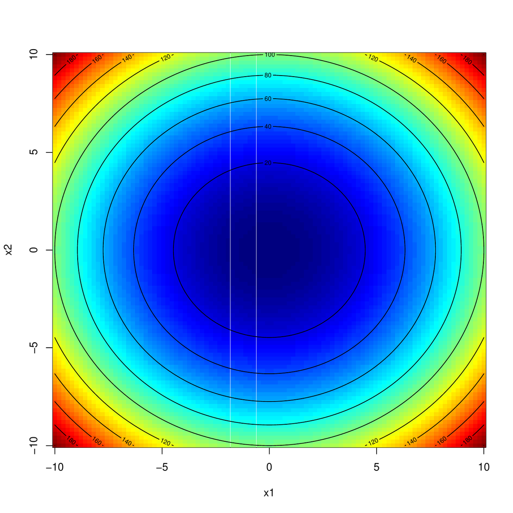

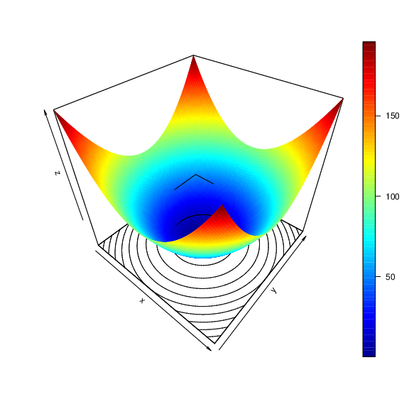

Figure 1: Contour plot (left) and 3D plot (right) of the two-dimensional Sphere function.

```r
> plot3D(fn, contour = TRUE)
```

If you prefer the visually appealing graphics of [*ggplot2*](https://CRAN.R-project.org/package=ggplot2) (Wickham 2009) you can make use of `autoplot`, which returns a `ggplot2` object. The returned `ggplot` object can be easily modified with additional geometric objects, statistical transformations and layers. For instance, let us visualize the mixed parameter function `fn2` which was introduced in the previous subsection. Here we activate ggplot2 facetting via `use.facets = TRUE`, flip the default facet direction and adapt the limits of the objective axis by hand. Figure 2 shows the resulting plot.

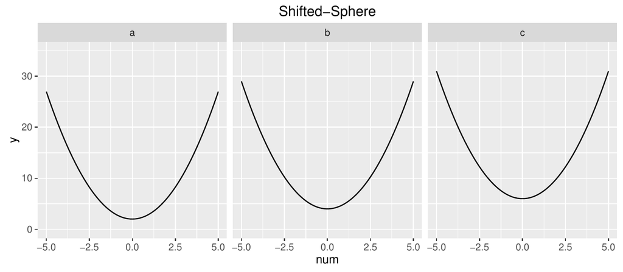

Figure 2: Plot of the mixed decisions space shifted Sphere function.

```r
library(ggplot2)
pl <- autoplot(fn2, use.facets = TRUE) # basic call
pl + ylim(c(0, 35)) + facet_grid(. ~ disc) # (one column per discrete value)
```

In particular, due to the possibility to subsequently modify the `ggplot` objects returned by the `autoplot` function it can be used effectively in other packages to, e. g., visualize an optimization process. For instance the *ecr* package makes extensive use of *smoof* functions and the *ggplot2* plots.

### 3.4 Getter methods

Accessing the describing attributes of a *smoof* function is essential and can be simply realized by `attr("attrName", fn)` or alternatively via a set of helper functions. The latter approach is highly recommended. By way of example the following listing shows just a few of the available helpers.

```r
> getGlobalOptimum(fn)$param
  x1 x2
1  0  0
> getGlobalOptimum(fn)$value
[1] 0
> getGlobalOptimum(fn)$is.minimum
[1] TRUE
> getNumberOfParameters(fn)
[1] 2
> getNumberOfObjectives(fn)
[1] 1
> getLowerBoxConstraints(fn)
  x1  x2
 -10 -10
```

## 4 Predefined test function generators

Extending *smoof* with custom objective functions is nice to have, but the main benefit in using this package is the large set of preimplemented functions typically used in the optimization literature. At the moment of writing there are in total 72 single objective functions and 24 multi-objective function generators available. Moreover there are interfaces to some more specialized benchmark sets and problem generators which will be mentioned in the next section.

### 4.1 Generators for single-objective test functions

To apply some optimization routines to say the Sphere function you do not need to define it by hand. Instead you can just call the corresponding generator function, which has the form `makeFUNFunction` where `FUN` may be replaced with one of the function names. Hence, the Sphere function can be generated by calling `makeSphereFunction(dimensions = 2L)`, where the integer `dimensions` argument defines the dimension of the search space for scalable objective functions, i. e., functions which are defined for arbitrary parameter space dimensions $n \geq 2$. All $72$ single-objective functions with their associated tags are listed in Table 1. The tags are based on the test function survey in (Jamil and Yang 2013). Six functions with very different landscapes are visualized in Figure 3.

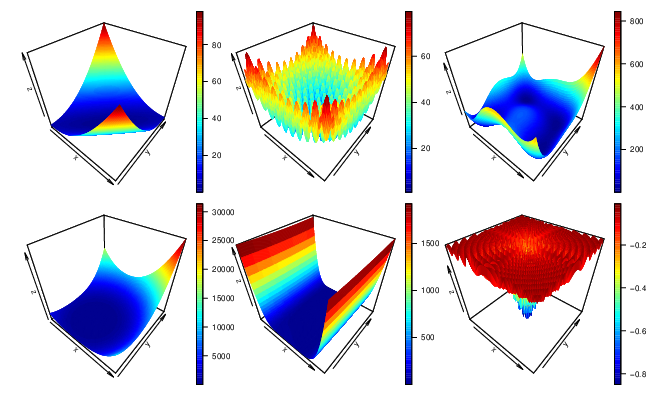

Figure 3: Two-dimensional test functions *Matyas* (top left), *Rastrigin* (top middle), *Himmelblau* (top right), *Zettl* (bottom left), *Three Hump Camel* (bottom middle) and *Generalized Drop Wave* (bottom right).

Beside these functions there exist two additional single-objective generators, which interface special test function sets or function generators.

**BBOB**

The $24$ Black-Box Optimization Benchmark (BBOB) 2009 (Hansen et al. 2009) functions can be created with the `makeBBOBFunction(fid, iid, dimension)` generator, where `fid` $\in \{1, \ldots, 24\}$ is the function identifier, `iid` is the instance identifier and `dimension` the familiar argument for specifying the parameter space dimension.

**MPM2**

The problem generator *multiple peaks model 2* (Wessing 2015) is accessible via the function `makeMPM2Function`. This problem generator produces multimodal problem instances by combining several randomly distributed peaks (Wessing 2015). The number of peaks can be set via the `n.peaks` argument. Further arguments are the problem `dimension`, an initial `seed` for the random numbers generator and the `topology`, which accepts the values `random` or `funnel` respectively. For details see the technical report of the multiple peaks model 2 Wessing (2015).

Table 1: All single objective functions currently available in *smoof* with their corresponding tags.

| Function | Tags |
| --- | --- |
| Ackley | continuous, multimodal, differentiable, non-separable, scalable |
| Adjiman | continuous, differentiable, non-separable, non-scalable, multimodal |
| Alpine N. 1 | continuous, non-differentiable, separable, scalable, multimodal |
| Alpine N. 2 | continuous, differentiable, separable, scalable, multimodal |
| Aluffi-Pentini | continuous, differentiable, non-separable, non-scalable, unimodal |
| Bartels Conn | continuous, non-differentiable, non-separable, non-scalable, multimodal |
| Beale | continuous, differentiable, non-separable, non-scalable, unimodal |
| Bent-Cigar | continuous, differentiable, non-separable, scalable, unimodal |
| Bird | continuous, differentiable, non-separable, non-scalable, multimodal |
| BiSphere | multi-objective |
| Bohachevsky N. 1 | continuous, differentiable, separable, scalable, multimodal |
| Booth | continuous, differentiable, non-separable, non-scalable, unimodal |
| BraninRCOS | continuous, differentiable, non-separable, non-scalable, multimodal |
| Brent | continuous, differentiable, non-separable, non-scalable, unimodal |
| Brown | continuous, differentiable, non-separable, scalable, unimodal |
| Bukin N. 2 | continuous, differentiable, non-separable, non-scalable, multimodal |
| Bukin N. 4 | continuous, non-differentiable, separable, non-scalable, multimodal |
| Bukin N. 6 | continuous, non-differentiable, non-separable, non-scalable, multimodal |
| Carrom Table | continuous, differentiable, non-separable, non-scalable, multimodal |
| Chichinadze | continuous, differentiable, separable, non-scalable, multimodal |
| Chung Reynolds | unimodal, continuous, differentiable, scalable |
| Complex | continuous, differentiable, non-separable, non-scalable, multimodal |
| Cosine Mixture | discontinuous, non-differentiable, separable, scalable, multimodal |
| Cross-In-Tray | continuous, non-separable, non-scalable, multimodal |
| Cube | continuous, differentiable, non-separable, non-scalable, unimodal |
| Deckkers-Aarts | continuous, differentiable, non-separable, non-scalable, multimodal |
| Deflected Corrugated Spring | continuous, differentiable, non-separable, scalable, multimodal |
| Dixon-Price | continuous, differentiable, non-separable, scalable, unimodal |
| Double-Sum | convex, unimodal, differentiable, separable, scalable, continuous |
| Eason | continuous, differentiable, separable, non-scalable, multimodal |
| Egg Crate | continuous, separable, non-scalable |
| Egg Holder | continuous, differentiable, non-separable, multimodal |
| El-Attar-Vidyasagar-Dutta | continuous, differentiable, non-separable, non-scalable, unimodal |
| Engvall | continuous, differentiable, non-separable, non-scalable, unimodal |
| Exponential | continuous, differentiable, non-separable, scalable |
| Freudenstein Roth | continuous, differentiable, non-separable, non-scalable, multimodal |
| Generelized Drop-Wave | multimodal, non-separable, continuous, differentiable, scalable |
| Giunta | continuous, differentiable, separable, multimodal |
| Goldstein-Price | continuous, differentiable, non-separable, non-scalable, multimodal |
| Griewank | continuous, differentiable, non-separable, scalable, multimodal |
| Hansen | continuous, differentiable, separable, non-scalable, multimodal |
| Himmelblau | continuous, differentiable, non-separable, non-scalable, multimodal |
| Holder Table N. 1 | continuous, differentiable, separable, non-scalable, multimodal |
| Holder Table N. 2 | continuous, differentiable, separable, non-scalable, multimodal |
| Hosaki | continuous, differentiable, non-separable, non-scalable, multimodal |
| Hyper-Ellipsoid | unimodal, convex, continuous, scalable |
| Jennrich-Sampson | continuous, differentiable, non-separable, non-scalable, unimodal |
| Judge | continuous, differentiable, non-separable, non-scalable, multimodal |
| Keane | continuous, differentiable, non-separable, non-scalable, multimodal |
| Kearfott | continuous, differentiable, non-separable, non-scalable, multimodal |
| Leon | continuous, differentiable, non-separable, non-scalable, unimodal |
| Matyas | continuous, differentiable, non-separable, non-scalable, unimodal |
| McCormick | continuous, differentiable, non-separable, non-scalable, multimodal |
| Michalewicz | continuous, multimodal, scalable |
| Periodic | continuous, differentiable, non-separable, non-scalable, multimodal |
| Double-Sum | continuous, differentiable, separable, scalable, unimodal |
| Price N. 1 | continuous, non-differentiable, separable, non-scalable, multimodal |
| Price N. 2 | continuous, differentiable, non-separable, non-scalable, multimodal |
| Price N. 4 | continuous, differentiable, non-separable, non-scalable, multimodal |
| Rastrigin | multimodal, continuous, separable, scalable |
| Rosenbrock | continuous, differentiable, non-separable, scalable, multimodal |
| Schaffer N. 2 | continuous, differentiable, non-separable, non-scalable, unimodal |
| Schaffer N. 4 | continuous, differentiable, non-separable, non-scalable, unimodal |
| Schwefel | continuous, multimodal, scalable |
| Shubert | continuous, differentiable, non-scalable, multimodal |
| Six-Hump Camel Back | continuous, differentiable, non-separable, non-scalable, multimodal |
| Sphere | unimodal, separable, convex, continuous, differentiable, scalable |
| Styblinkski-Tang | continuous, differentiable, non-separable, non-scalable, multimodal |
| Sum of Different Squares | unimodal, continuous, scalable |
| Swiler2014 | discontinuous, mixed, multimodal |
| Three-Hump Camel | continuous, differentiable, non-separable, non-scalable, multimodal |
| Trecanni | continuous, differentiable, separable, non-scalable, unimodal |
| Zettl | continuous, differentiable, non-separable, non-scalable, unimodal |

### 4.2 Generators for multi-objective test functions

Evolutionary algorithms play a crucial role in solving multi-objective optimization tasks. The relative performance of *mutli-objective evolutionary algorithms* (MOEAs) is, as in the single-objective case, mainly studied experimentally by systematic comparison of performance indicators on test instances. In the past decades several test sets for multi-objective optimization were proposed mainly by the evolutionary computation community. The *smoof* package offers generators for the DTLZ function family by Deb et al. (Deb et al. 2002), the ZDT function family by Zitzler et al. (Zitzler et al. 2000) and the multi-objective optimization test instances UF1, …, UF10 of the CEC 2009 special session and competition (Zhang et al. 2009).

The DTLZ generators are named `makeDTLZXFunction` with X = $1, \ldots, 7$. All DTLZ generators need the search space dimension $n$ (argument `dimensions`) and the objective space dimension $p$ (argument `n.objectives`) with $n \geq p$ to be passed. DTLZ4 may be passed an additional argument `alpha` with default value 100, which is recommended by Deb et al. (2002). The following lines of code generate the DTLZ2 function and visualize its Pareto-front by running the NSGA-II EMOA implemented in the *mco* package with a population size of 100 for 100 generations (see Figure 4).

```r
> fn = makeDTLZ2Function(dimensions = 2L, n.objectives = 2L)
> visualizeParetoOptimalFront(fn, show.only.front = TRUE)
```

ZDT and UF functions can be generated in a similar manner by utilizing `makeZDTXFunction` with X = $1, \ldots, 5$ or `makeUFFunction`.

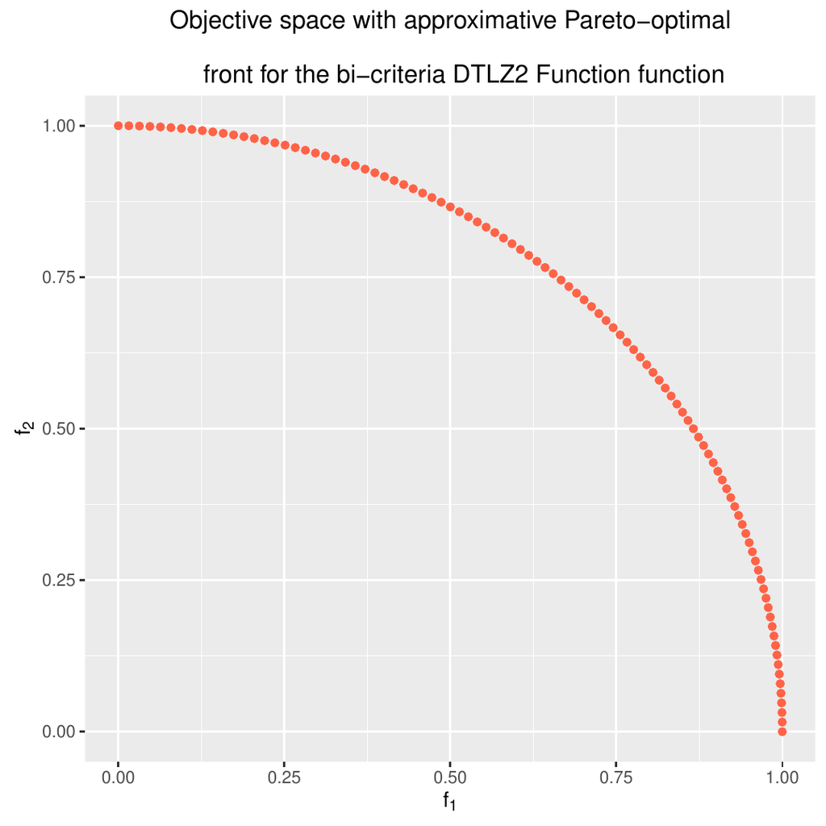

Figure 4: Visualization of the approximated Pareto-front for the DTLZ2 function with two-dimensional search and objective space.

## 5 Optimization helpers

In this section we present some additional helper methods which are available in *smoof*.

### 5.1 Filtering and building of test sets

In a benchmark study we most often need not just a single test function, but a set of test functions with certain properties. Say we want to benchmark an algorithm on all multimodal smoof functions. Instead of scouring the smoof documentation for suitable test functions we can make use of the `filterFunctionsByTags` helper function. This function has only a single mandatory argument, namely a character vector of `tags`. Hence, to get an overview of all multimodal functions we can write the following:

```r
> fn.names <- filterFunctionsByTags(tags = "multimodal")
> head(fn.names)
[1] "Ackley"       "Adjiman"      "Alpine N. 1"  "Alpine N. 2"  "Bartels Conn"
[6] "Bird"
> print(length(fn.names))
[1] 46
```

The above shows there are 46 multimodal functions. The next step is to generate the actual smoof functions. We could do this by hand, but this would be tedious work. Instead we utilize the `makeFunctionsByName` helper function which comes in useful in combination with filtering. It can be passed a vector of generator names (like the ones returned by `filterFunctionsByTags`) and additional arguments which are passed down to the generators itself. E. g., to initialize all two-dimensional multimodal functions, we can apply the following function call.

```r
> fns <- makeFunctionsByName(fn.names, dimensions = 2)
> all(sapply(fns, isSmoofFunction))
[1] TRUE
> print(length(fns))
[1] 46
> print(fns[[1L]])
Single-objective function
Name: 2-d Ackley Function
Description: no description
Tags: single-objective, continuous, multimodal, differentiable, non-separable, scalable
Noisy: FALSE
Minimize: TRUE
Constraints: TRUE
Number of parameters: 2
           Type len Def                   Constr Req Tunable Trafo
x numericvector   2   - -32.8,-32.8 to 32.8,32.8   -    TRUE     -
Global optimum objective value of 0.0000 at
  x1 x2
1  0  0
```

### 5.2 Wrapping functions

The *smoof* package ships with some handy wrappers. These are functions which expect a *smoof* function and possibly some further arguments and return a *wrapped* *smoof* function, which behaves as the original and does some secret logging additionally. We can wrap a *smoof* function within a *counting wrapper* (function `addCountingWrapper`) to count the number of function evaluations. This is of particular interest, if we compare stochastic optimization algorithms and the implementations under consideration do not return the number of function evaluations carried out during the optimization process. Moreover, we might want to log each function value along the optimization process. This can be achieved by means of a *logging wrapper*. The corresponding function is `addLoggingWrapper`. By default it logs just the test function values (argument `logg.y` is `TRUE` by default). Optionally the logging of the decision space might be activated by setting the `logg.x` argument to `TRUE`. The following listing illustrates both wrappers by examplary optimizing the Branin RCOS function with the Nelder-Mead Simplex algorithm.

```r
> set.seed(123)
> fn <- makeBraninFunction()
> fn <- addCountingWrapper(fn)
> fn <- addLoggingWrapper(fn, logg.x = TRUE, logg.y = TRUE)
> par.set <- getParamSet(fn)
> lower <- getLower(par.set); upper = getUpper(par.set)
> res <- optim(c(0, 0), fn = fn, method = "Nelder-Mead")
> res$counts[1L] == getNumberOfEvaluations(fn)
[1] TRUE
> head(getLoggedValues(fn, compact = TRUE))
    x1   x2    y1
1 0.00 0.00 55.60
2 0.10 0.00 53.68
3 0.00 0.10 54.41
4 0.10 0.10 52.53
5 0.15 0.15 51.01
6 0.25 0.05 50.22
```

## 6 Conclusion and future work

Benchmarking optimization algorithms on a set of artificial test functions with well-known characteristics is an established means of evaluating performance in the optimization community. This article introduces the R package *smoof*, which contains a large collection of continuous test functions for the single-objective as well as the multi-objective case. Besides a set of helper functions is introduced which allows users to log in detail the progress of the optimization algorithm(s) studied. Future work will lay focus on implementing more continuous test functions, introducing test functions with mixed parameter spaces and provide reference Pareto-sets and Pareto-Fronts for the multi-objective functions. Furthermore the reduction of evaluation time by rewriting existing functions in C(++) is planned.

### 6.1 CRAN packages used

emoa, mco, ecr, cec2005benchmark, cec2013, globalOptTests, soobench, smoof, ParamHelpers, ggplot2

### 6.2 CRAN Task Views implied by cited packages

ChemPhys, NetworkAnalysis, Optimization, Phylogenetics, Spatial, TeachingStatistics

B. Bischl, M. Lang, J. Bossek, D. Horn, J. Richter and P. Kerschke. *ParamHelpers: Helpers for Parameters in Black-Box Optimization, Tuning and Machine Learning.* 2016. URL https://github.com/berndbischl/ParamHelpers. R package version 1.9.

J. Bossek. *ecr: Evolutionary Computation in R.* 2017a. URL https://github.com/jakobbossek/ecr2. R package version 2.0.0.

J. Bossek. *smoof: Single and Multi-Objective Optimization Test Functions.* 2017b. URL https://github.com/jakobbossek/smoof. R package version 1.5.

C. A. C. Coello, G. B. Lamont and D. A. Van Veldhuizen. *Evolutionary algorithms for solving multi-objective problems (genetic and evolutionary computation).* Secaucus, NJ, USA: Springer-Verlag, 2006. URL https://doi.org/10.1007/978-0-387-36797-2.

K. Deb, L. Thiele, M. Laumanns and E. Zitzler. Scalable multi-objective optimization test problems. In *Evolutionary computation, 2002. CEC ’02. Proceedings of the 2002 congress on*, pages. 825–830 2002. URL https://doi.org/10.1109/cec.2002.1007032.

Y. Gonzalez-Fernandez and M. Soto. *cec2005benchmark: Benchmark for the CEC 2005 Special Session on Real-Parameter Optimization.* 2015. URL http://CRAN.R-project.org/package=cec2005benchmark. R package version 1.0.4.

N. Hansen, S. Finck, R. Ros and A. Auger. Real-parameter black-box optimization benchmarking 2009: Noiseless functions definitions. RR-6829. INRIA. 2009.

S. Huband, P. Hingston, L. Barone and R. L. While. A review of multiobjective test problems and a scalable test problem toolkit. *IEEE Trans. Evolutionary Computation*, 10(5): 477–506, 2006. URL https://doi.org/10.1109/TEVC.2005.861417.

M. Jamil and X.-S. Yang. A literature survey of benchmark functions for global optimisation problems. *IJMNO*, 4(2): 150–194, 2013. URL https://doi.org/10.1504/ijmmno.2013.055204.

P. Kerschke and J. Dagefoerde. *flacco: Feature-Based Landscape Analysis of Continuous and Constraint Optimization Problems.* 2015. URL http://CRAN.R-project.org/package=flacco. R package version 1.1.

O. Mersmann. *emoa: Evolutionary Multiobjective Optimization Algorithms.* 2012. URL http://CRAN.R-project.org/package=emoa. R package version 0.5-0.

O. Mersmann. *mco: Multiple Criteria Optimization Algorithms and Related Functions.* 2014. URL http://CRAN.R-project.org/package=mco. R package version 1.0-15.1.

O. Mersmann and B. Bischl. *soobench: Single Objective Optimization Benchmark Functions.* 2012. URL http://CRAN.R-project.org/package=soobench. R package version 1.0-73.

K. M. Mullen. Continuous global optimization in R. *JOURNAL of Statistical Software*, 60(6): 1–45, 2014. URL https://doi.org/10.18637/jss.v060.i06.

S. Theussl and H. W. Borchers. CRAN task view: Optimization and mathematical programming. Version 2015-11-17.

S. Wessing. The multiple peaks model 2. TR15-2-001. TU Dortmund. 2015.

H. Wickham. *ggplot2: Elegant Graphics for Data Analysis.* Springer-Verlag, 2009. URL https://doi.org/10.1007/978-0-387-98141-3.

M. Zambrano-Bigiarini and Y. Gonzalez-Fernandez. *cec2013: Benchmark Functions for the Special Session and Competition on Real-Parameter Single Objective Optimization at CEC-2013.* 2015. URL http://CRAN.R-project.org/package=cec2013. R package version 0.1-5.

Q. Zhang, A. Zhou, S. Zhao, P. N. Suganthan and W. Liu. Multiobjective optimization test instances for the CEC 2009 special session and competition. CES-487. School of Computer Science; Electronic Engieering, University of Essex, Colchester. 2009.

E. Zitzler, K. Deb and L. Thiele. Comparison of multiobjective evolutionary algorithms: Empirical results. *Evolutionary Computation*, 8: 173–195, 2000. URL https://doi.org/10.1162/106365600568202.